# Lactate-Discordance

Nuria

30/7/2019

# Lactate Discordance Project: Exploratory Analysis of Lactate in MIMIC-III, eICU and HJ23 by Illness Severity

This notebook extracts the maximum lactate in the first 24 hours for all patients in the three databases. After excluding patients with length of stay below 24 hours, those lacking data, and those under the age of 16, the lactate levels are grouped using deciles and quartiles of each severity of illness score.

# Libraries

```r
require(dbplyr)
require(dplyr)
require(RPostgreSQL)
require(sqldf)
require(tidyverse)
require(reshape2)
require(lubridate)
require(mice)
require(caret)
require(ROCR)
```

# 1 - Load variables

## 1.1 - Load HJ23 variables

HJ23 database is imported with csv files. Data information of patients, ICU lab variables and vasopressors doses for the first 24 hours. The number of vars here corresponds to an initial subset of vars that will be modified in next steps. (These files will be included in the project when the Ethic Committee of our Hospital approves the project)

```r
pats <- read.csv("C:/Lactate/LACTATE_PROJECT/Patients.csv",dec = ',')
vars <- read.csv("C:/Lactate/LACTATE_PROJECT/Vars.csv",dec = ',')
drugs <- read.csv("C:/Lactate/LACTATE_PROJECT/Drugs.csv",dec = ',')
other_vars <- read.csv("C:/Lactate/LACTATE_PROJECT/VarsAddition.csv",dec = ',')

colnames(pats)[1] <- 'PatientID'
colnames(vars)[1] <- 'PatientID'
colnames(drugs)[1] <- 'PatientID'
colnames(other_vars)[1] <- 'PatientID'
```

### Clean and transform data

Transform all the information into a dataframe with a label for each variable.

```r
#delete columns
num_features <- select(vars, PatientID, VarName, MinValue, MaxValue, MedianValue)
#delete repeated entries
num_features2 <- as.data.frame(num_features %>% distinct(PatientID, VarName,
                                                         .keep_all = TRUE))

rm(num_features)
#Dataframe with drugs' patients
base <- as.data.frame(drugs[,1])
base <- unique(base)
colnames(base)[1]<-'PatientID'
base <- as.data.frame(base[order(base$PatientID),])
colnames(base)[1]<-'PatientID'

#Restructure the data of drugs
add <- dcast(data = drugs, PatientID ~ drugs[,2], value.var = colnames(drugs)[3])
add <- add[order(add$PatientID),]
add <- add[,2:ncol(add)]
colnames(add) <- paste(colnames(add), colnames(drugs)[3], sep = "_")
base <- cbind(base,add)

#Add label total drug dose and number of drugs per patient
base$num_drugs <-rowSums(!is.na(base[,2:4]))
base[is.na(base)] <- 0
base$total_dose <- rowSums(base[,2:4])

#dataframe with vars' patients
base2 <- as.data.frame(num_features2[,1])
base2 <- unique(base2)
colnames(base2)[1]<-'PatientID'
base2 <- as.data.frame(base2[order(base2$PatientID),])
colnames(base2)[1]<-'PatientID'

#Restructure the data of vars
for (i in 3:ncol(num_features2)){
  add2 <- dcast(data = num_features2, PatientID ~ num_features2[,2],
                value.var = colnames(num_features2)[i])
  add2$ABPm_combined <- ifelse(is.na(add2$ABPm)==T & is.na(add2$`ABPm NI`)==F,
                               add2$`ABPm NI`,add2$ABPm)
  add2$ABPm <- NULL
  add2$`ABPm NI`<- NULL
  add2$ABPd <- NULL
  add2$`ABPd NI`<- NULL
  add2$ABPs <- NULL
  add2$`ABPs NI`<- NULL
  add2 <- add2[order(add2$PatientID),]
  add2 <- add2[,2:ncol(add2)]
  colnames(add2) <- paste(colnames(add2), colnames(num_features2)[i], sep = "_")
  base2 <- cbind(base2,add2)
}
rm(add)
rm(add2)
rm(num_features2)
pats2<-pats[!duplicated(pats$PatientID), ]
#unify all data in "taula_res"
taula_res<- left_join(pats2, base, by="PatientID")
taula_res <- left_join(taula_res, base2, by="PatientID")

taula_res$total_dose[is.na(taula_res$total_dose)] <- 0
taula_res$num_drugs[is.na(taula_res$num_drugs)] <- 0

taula_res$VMI[is.na(taula_res$VMI)] <- 0
taula_res$VMI <- as.factor(as.character(taula_res$VMI))

taula_res$Dobutamine_Dose[is.na(taula_res$Dobutamine_Dose)] <- 0
taula_res$Dopamine_Dose[is.na(taula_res$Dopamine_Dose)] <- 0
taula_res$Noradrenaline_Dose[is.na(taula_res$Noradrenaline_Dose)] <- 0

rm(base)
rm(base2)
colnames(taula_res) <- gsub("/", "", colnames(taula_res))
```

### Add Cl, AST, ALT, alkaline phosphatase from other_vars

At this point we decidied to add some vars of interest that we did not take into account during the first selection process.

```r
cl <- other_vars[which(other_vars$VariableID==24000644 | other_vars$VariableID==24000713), ]
cl_median<- cl%>%
group_by(PatientID)%>%
summarise(Chlorine_max=mean(MaxValue), Chlorine_min=mean(MinValue))

ast <- other_vars[which(other_vars$VariableID==24000641 | other_vars$VariableID==24000710), ]
ast_median<- ast%>%
group_by(PatientID)%>%
summarise(AST_max=mean(MaxValue), AST_min=mean(MinValue))

alt <- other_vars[which(other_vars$VariableID==24000707 | other_vars$VariableID==24000638), ]
alt_median<- alt%>%
group_by(PatientID)%>%
summarise(ALT_max=mean(MaxValue), ALT_min=mean(MinValue))


phosphatase <- other_vars[which(other_vars$VariableID==24000723), ]
phos_median<- alt%>%
group_by(PatientID)%>%
summarise(alkaline_phosphatase_max=mean(MaxValue), alkaline_phosphatase_min=mean(MinValue))

taula_res<-left_join(taula_res,cl_median, by='PatientID')
taula_res<-left_join(taula_res,alt_median, by='PatientID')
taula_res<-left_join(taula_res,ast_median, by='PatientID')
taula_res<-left_join(taula_res,phos_median, by='PatientID')

rm(cl_median, alt_median, ast_median, phos_median, phosphatase, drugs, pats, vars, other_vars, cl, ast, alt)
```

### Subset interest varaibles

From the total set of vars we generate a new subset after the latest meeting. We take advantatge of an excel file which contains the final number of vars of interest. (The subset2.csv is included in the project)

```r
taula_res$outcome<-"NULL"
vars_sign <- read.csv("C:/Lactate/LACTATE_PROJECT/subset2.csv",sep = ';')

variables<-vars_sign[complete.cases(vars_sign$model), ]

variables$X <- NULL

sign <- as.vector(variables[,1])
taula_res <- select(taula_res, sign)

taula_res<-taula_res[complete.cases(taula_res$Lactate_MaxValue), ]
rm(sign, variables, vars_sign)
```

## 0.2 - Environment Setup MIMIC-III

We have MIMIC-III hosted in a local Postgres database on Windows, we built all tables and all materialized views (concepts) as well. (https://mimic.physionet.org/tutorials/install-mimic-locally-windows/).

```r
# connexion:
drv <- dbDriver("PostgreSQL")
con <- dbConnect(drv, dbname="postgres",host="localhost",port=5432,user="postgres",password="postgres")

# parametrisation of the sqldf function.
options(sqldf.RPostgreSQL.user = "postgres"
        , sqldf.RPostgreSQL.password = "postgres"
        , sqldf.RPostgreSQL.dbname = "postgres"
        , sqldf.RPostgreSQL.host = "localhost"
        , sqldf.RPostgreSQL.port = 5432)
```

## 1.2 - Load MIMIC-III variables

Load variables from MIMIC-III database from the first 24 hours in ICU.

### Load ICUintime, LOS, age and gender

```r
dbDisconnect(con)
```

```
## [1] TRUE
```

```r
#Load icustays table

query <- 'SELECT icustay_id, subject_id, hadm_id, intime FROM icustays'
T_icustays <- sqldf(query)
#Load DOB, DOD and Gender of patients
query <- 'SELECT subject_id, dod_hosp FROM patients'
 T_patients <- sqldf(query)

 T_icustays <- left_join(T_icustays, T_patients, by="subject_id")
 T_icustays$subject_id<-NULL
 rm(T_patients)
```

### Load labs variables

In order to take advantatge of the sql script that generates the labsfirstday values of mimic concepts we edited the script to include some vars of interest, and generated the materialized view labsfirstday_2. Users need to run it in the same way they run the regular labsfirstday during the built of the materialized concepts. (The sql script is included in the project).

```r
LacFirstDay_Q <- 'SELECT * FROM labsfirstday_2 WHERE lactate_max IS NOT NULL'
LacFirstDay <- sqldf(LacFirstDay_Q)
rm(LacFirstDay_Q)
LacFirstDay$subject_id<-NULL
LacFirstDay$hadm_id<-NULL
```

### Load oasis

```r
OASIS_Q <- 'SELECT icustay_id, oasis FROM oasis'
OASIS <- sqldf(OASIS_Q)
rm(OASIS_Q)
```

### Load age, gender and LOS

```r
Adults24hLOSmin_Q <- 'SELECT icustay_id, gender, admission_age, los_icu FROM icustay_detail'
Adults24hLOSmin <- sqldf(Adults24hLOSmin_Q)
rm(Adults24hLOSmin_Q)
```

### Load VMI

```r
#Load procedureevents_mv table
query <- 'SELECT icustay_id, vent FROM ventfirstday'
T_VMI <- sqldf(query)
T_VMI$vent <- as.factor(T_VMI$vent)

rm(query)
```

### Load Vassopressors (Dobutamine, Dopamine, Norepinephrine)

```r
#Load inputevent_mv table
query <- 'SELECT itemid, icustay_id, amount, starttime FROM inputevents_mv WHERE itemid IN (221653,221662,221906)'
T_vars_inputevents <- sqldf(query)

rm(query)
T_vars_inputevents <- as.data.frame(T_vars_inputevents %>% distinct(icustay_id, itemid, starttime, .keep_all = TRUE))

names(T_vars_inputevents)[names(T_vars_inputevents)=="starttime"] <- "charttime"
names(T_vars_inputevents)[names(T_vars_inputevents)=="amount"] <- "valuenum"
#Join tables
T_vars_times<- inner_join(T_icustays, T_vars_inputevents, by= "icustay_id")
#time of measure first 24h
T_vars_times$measure_time <- (ymd(T_vars_times$charttime) - ymd(T_vars_times$intime))
T_vars_times_1stday <- T_vars_times[which(T_vars_times$measure_time<2),]

rm(T_vars_times)
#Calculate max and min
T_vars_times_1stdayG<- T_vars_times_1stday%>%
group_by(icustay_id, itemid)%>%
summarise(max=max(valuenum), min=min(valuenum), intime=mean(intime), charttime=mean(charttime))

#change item_id number for name
T_vars_times_1stdayG$itemid <- ifelse(T_vars_times_1stdayG$itemid==221653,"Dobutamine",
                                      ifelse(T_vars_times_1stdayG$itemid==221662,"Dopamine",'Norepinephrine'))

#Restructure the data
Cohort <- as.data.frame(T_vars_times_1stdayG[,1])
Cohort <- unique(Cohort)
colnames(Cohort)[1]<-'icustay_id'
Cohort <- as.data.frame(Cohort[order(Cohort$icustay_id),])
colnames(Cohort)[1]<-'icustay_id'


for (i in 3:4){
add <- dcast(data = T_vars_times_1stdayG, icustay_id ~ itemid, value.var = colnames(T_vars_times_1stdayG)[i])
add <- add[order(add$icustay_id),]
add <- add[,2:ncol(add)]
colnames(add) <- paste(colnames(add), colnames(T_vars_times_1stdayG)[i], sep = "_")
 Cohort <- cbind(Cohort,add)
}
```

### Load Admissions

```r
query <- 'SELECT hadm_id, admittime, admission_type FROM admissions'
admission <- sqldf(query)

admi <- left_join(T_icustays, admission, by= "hadm_id")
library(lubridate)
admi$days_before_icu <- (ymd(admi$intime) - ymd(admi$admittime))

rm(query, admission)
```

### Join variables

```r
CohortMIMIC<-left_join(LacFirstDay, Cohort, by="icustay_id")
CohortMIMIC<- left_join(CohortMIMIC, OASIS, by="icustay_id")
CohortMIMIC<-left_join(CohortMIMIC, Adults24hLOSmin, by="icustay_id")
CohortMIMIC<-left_join(CohortMIMIC, T_VMI, by="icustay_id")
CohortMIMIC<- left_join(CohortMIMIC, admi, by="icustay_id")
CohortMIMIC$admittime<-NULL
CohortMIMIC$hadm_id<-NULL
CohortMIMIC$intime<-NULL
CohortMIMIC$admission_type <- as.factor(CohortMIMIC$admission_type)
CohortMIMIC$gender <- as.factor(CohortMIMIC$gender)

rm(LacFirstDay, OASIS, Adults24hLOSmin, T_VMI, admi, T_vars_inputevents, T_vars_times_1stday, T_vars_times_1stdayG, T_icustays, Cohort)
```

## 0.3 - eICU

eICU database is also hosted in a local Postgres database on Windows. (https://eicu-crd.mit.edu/tutorials/install_eicu_locally/) We built all tables and all materialized views (concepts) as well.

```r
# connexion:
drv2 <- dbDriver("PostgreSQL")
con2 <- dbConnect(drv, dbname="eicu",host="localhost",port=5432,user="postgres",password="postgres")

# parametrisation of the sqldf function.
options(sqldf.RPostgreSQL.user = "postgres"
        , sqldf.RPostgreSQL.password = "postgres"
        , sqldf.RPostgreSQL.dbname = "eicu"
        , sqldf.RPostgreSQL.host = "localhost"
        , sqldf.RPostgreSQL.port = 5432)
```

## 1.3 - Load eICU variables

### Load lab variables

In order to take advantatge of the sql script that generates the labsfirstday values of eicu concepts we edited the script to include some vars of interest, and generated the materialized view labsfirstday_modif. Users need to run it in the same way they run the regular labsfirstday during the built of the materialized concepts. (The sql script is included in the project).

```r
dbDisconnect(con2)
```

```
## [1] TRUE
```

```r
LacFirstDay_Q <- 'SELECT * FROM eicu.labsfirstday_modif WHERE lactate_max IS NOT NULL'
T_lact_lab <- sqldf(LacFirstDay_Q)
rm(LacFirstDay_Q)
T_lact_lab$uniquepid<-NULL
T_lact_lab$patienthealthsystemstayid<-NULL

T_lact_lab <- as.data.frame(T_lact_lab %>% distinct(patientunitstayid,
                                                         .keep_all = TRUE))
T_lact_lab$bun_min<-NULL
```

### Load unittype, gender, age, apache_iv, hosp_mort, icu_los_hours

```r
Q <- 'SELECT patientunitstayid, unittype, gender, age, hosp_mort, icu_los_hours FROM eicu.icustay_detail'
T_icustay_eicu <- sqldf(Q)
T_icustay_eicu$unittype <- as.factor(T_icustay_eicu$unittype)
rm(Q)
T_icustay_eicu <- T_icustay_eicu %>%  rename(outcome = hosp_mort)
T_icustay_eicu$outcome<-as.factor(ifelse(T_icustay_eicu$outcome==1,'Dead','Alive'))
T_icustay_eicu$icu_los <- T_icustay_eicu$icu_los_hours/24
T_icustay_eicu$icu_los_hours<-NULL
T_icustay_eicu$age <- ifelse(T_icustay_eicu$age == '> 89',91.3,T_icustay_eicu$age)
T_icustay_eicu$age <- as.numeric(T_icustay_eicu$age)
T_icustay_eicu$gender <- as.factor(ifelse(T_icustay_eicu$gender==1,'M','F'))
T_icustay_eicu <- as.data.frame(T_icustay_eicu %>% distinct(patientunitstayid,
                                                         .keep_all = TRUE))
```

### Load VMI

```r
Q <- 'SELECT patientunitstayid, ventStartOffset FROM eicu.respiratorycare'
T_vent_eicu <- sqldf(Q)

T_vent_eicu$vent<-T_vent_eicu$ventstartoffset/60
## 1<- vent in the first 24h, 0<- No vent in the first 24h.
T_vent_eicu$vent<- ifelse(T_vent_eicu$vent>24 | T_vent_eicu$vent==0,0,1)
T_vent_eicu$ventstartoffset<-NULL
T_vent_eicu$vent<- as.factor(T_vent_eicu$vent)
T_vent_eicu <- as.data.frame(T_vent_eicu %>% distinct(patientunitstayid,
                                                         .keep_all = TRUE))
```

### Load apache IVa

```r
Q <- 'SELECT patientunitstayid, apacheScore, apacheVersion FROM eicu.apachePatientResult'
T_apache <- sqldf(Q)

T_apache <- T_apache[which(T_apache$apacheversion=='IVa'),]
T_apache$apacheversion<-NULL
T_apache <- as.data.frame(T_apache %>% distinct(patientunitstayid,
                                                         .keep_all = TRUE))
rm(Q)
```

### Load vasopressors

```r
query<- "SELECT patientunitstayid, norepinephrine, dopamine, dobutamine FROM eicu.pivoted_med WHERE chartoffset<=1440"
T_drugs <-sqldf(query)


T_drugs <- as.data.frame(T_drugs %>% distinct(patientunitstayid,
                                                         .keep_all = TRUE))
T_drugs$num_drugs<-rowSums(T_drugs[,2:4])
```

### Load days before icu

```r
query<- "SELECT patientunitstayid, hospitalAdmitOffset FROM eicu.patient WHERE hospitalAdmitOffset<=0"
T_days_before_icu <- sqldf(query)

T_days_before_icu$days_before_icu <- T_days_before_icu$hospitaladmitoffset/(60*24*-1)
T_days_before_icu$hospitaladmitoffset<-NULL


T_days_before_icu <- as.data.frame(T_days_before_icu %>% distinct(patientunitstayid,
                                                         .keep_all = TRUE))
```

### Join variables

```r
CohorteICU <- left_join(T_lact_lab, T_icustay_eicu, by= "patientunitstayid")
CohorteICU <- left_join(CohorteICU, T_vent_eicu, by= "patientunitstayid")
CohorteICU <- left_join(CohorteICU, T_apache, by= "patientunitstayid")
CohorteICU <- left_join(CohorteICU, T_drugs, by= "patientunitstayid")
CohorteICU <- left_join(CohorteICU, T_days_before_icu, by= "patientunitstayid")


rm(T_lact_lab, T_vent_eicu, T_apache, T_drugs, T_days_before_icu, T_icustay_eicu)
```

# 2 - Select patients

Select patients older than 16 and with and ICU_LOS longer than 24h.

## 2.1 - HJ23

```r
## Remove patients with less than 16 years

taula_res <- taula_res[which(taula_res$AgeAtAdm>=16),]
taula_res <- taula_res[which(taula_res$ICU_LOS>=1),]
```

## 2.2 - MIMIC-III

```r
CohortMIMIC <- CohortMIMIC[which(CohortMIMIC$admission_age>=16),]
CohortMIMIC$admission_age <- ifelse(CohortMIMIC$admission_age>200,91.3,CohortMIMIC$admission_age)

CohortMIMIC <- CohortMIMIC[which(CohortMIMIC$los_icu>=1),]
```

## 2.3 - eICU

```r
CohorteICU <- CohorteICU[which(CohorteICU$age>=16),]
CohorteICU <- CohorteICU[which(CohorteICU$icu_los>=1),]
```

# 3 - Create labels

Create extra labels for some important variables

## 3.1 - HJ23

### APACHE decile and quartile label

```r
# 2 APACHEII decile and quartile label
taula_res$APACHEIIdecile <- as.factor(ntile(taula_res$APACHEII, 10))

taula_res$APACHEIIquartile <- as.factor(ntile(taula_res$APACHEII, 4))
```

### Lactate label

Add 3 lactate labels for 3 different cutoff. lactate_label2 - (<2=Normal;>=2=High) lactate_label - (<2=Normal;>=4=High) lactate_label6 - (<2=Normal;>=6=High) ALso add a quartile lactate label

```r
# 3 Lactate Normal-High label

taula_res$lactate_label2 <- as.factor(ifelse(taula_res$Lactate_MaxValue<2,'Normal','High'))

taula_res$lactate_label <- as.factor(ifelse(taula_res$Lactate_MaxValue<2,'Normal',
                                            ifelse(taula_res$Lactate_MaxValue>=4,'High', 'Intermediate')))

taula_res$lactate_label6 <- as.factor(ifelse(taula_res$Lactate_MaxValue<2,'Normal',
                                            ifelse(taula_res$Lactate_MaxValue>=6,'High', 'Intermediate')))

taula_res$Lactate_MinValue<- NULL
taula_res$Lactate_MedianValue<- NULL

taula_res$lactate_quartile <- as.factor(ntile(taula_res$Lactate_MaxValue, 4))
```

### ICU-LOS quartile label

1-Very short period of time, 2-Short, 3-Large, 4-Very large

```r
# 4 ICU_LOS quartile label
taula_res$stay <- as.factor(ntile(taula_res$ICU_LOS, 4))
```

### Outcome label

Dead or alive outcome

```r
# 5 Outcome Dead-ALive label
taula_res$outcome <- as.factor(ifelse(taula_res$DisWardName=="EXITUS","Dead","Alive"))
taula_res$DisWardName<-NULL
```

## 3.2 - MIMIC-III

### Number o drugs and total dose

Count the total amount of drugs taken per patient and the total dose.

```r
CohortMIMIC$num_drugs <-rowSums(!is.na(CohortMIMIC[,23:25]))
CohortMIMIC$Dopamine_max[is.na(CohortMIMIC$Dopamine_max)] <- 0
CohortMIMIC$Dobutamine_max[is.na(CohortMIMIC$Dobutamine_max)] <- 0
CohortMIMIC$Norepinephrine_max[is.na(CohortMIMIC$Norepinephrine_max)] <- 0
```

### Make oasis decile and quartile label

```r
CohortMIMIC$oasis_decile <- as.factor(ntile(CohortMIMIC$oasis, 10))
CohortMIMIC$oasis_quartile <- as.factor(ntile(CohortMIMIC$oasis, 4))
#Cohort$oasis<-NULL
```

### Lactate level label

Add 3 lactate labels for 3 different cutoff. 2 - (<2=Normal;>=2=High) 4 - (<2=Normal;>=4=High) 6 - (<2=Normal;>=6=High)

```r
CohortMIMIC$lactate_label2 <- as.factor(ifelse(CohortMIMIC$lactate_max<2,'Normal','High'))


CohortMIMIC$lactate_label4 <- as.factor(ifelse(CohortMIMIC$lactate_max<2,'Normal',
                               ifelse(CohortMIMIC$lactate_max>=4,'High','Intermediate')))


CohortMIMIC$lactate_label6 <- as.factor(ifelse(CohortMIMIC$lactate_max<2,'Normal',
                               ifelse(CohortMIMIC$lactate_max>=6,'High','Intermediate')))

CohortMIMIC$lactate_quartile <- as.factor(ntile(CohortMIMIC$lactate_max, 4))
```

### LOS quartile label

Stay length

```r
CohortMIMIC$LOS_quartile <- as.factor(ntile(CohortMIMIC$los_icu, 4))
```

### Outcome label

If the patient has died in the hospital the outcome is Dead if not is Alive.

```r
 CohortMIMIC$outcome <- as.factor(ifelse(is.na(CohortMIMIC$dod_hosp),'Alive','Dead'))
 CohortMIMIC$dod_hosp<-NULL
```

## 3.3 - eICU

```r
CohorteICU$apacheIVa_decile <- as.factor(ntile(CohorteICU$apachescore, 10))
CohorteICU$apacheIVa_quartile <- as.factor(ntile(CohorteICU$apachescore, 4))
```

## Lactate level label

Add 3 lactate labels for 3 different cutoff. 2 - (<2=Normal;>=2=High) 4 - (<2=Normal;>=4=High) 6 - (<2=Normal;>=6=High)

```r
CohorteICU$lactate_label2 <- as.factor(ifelse(CohorteICU$lactate_max<2,'Normal','High'))


CohorteICU$lactate_label4 <- as.factor(ifelse(CohorteICU$lactate_max<2,'Normal',
                               ifelse(CohorteICU$lactate_max>=4,'High','Intermediate')))


CohorteICU$lactate_label6 <- as.factor(ifelse(CohorteICU$lactate_max<2,'Normal',
                               ifelse(CohorteICU$lactate_max>=6,'High','Intermediate')))

CohorteICU$lactate_quartile <- as.factor(ntile(CohorteICU$lactate_max, 4))
```

## LOS quartile label

Stay length

```r
CohorteICU$LOS_quartile <- as.factor(ntile(CohorteICU$icu_los, 4))
```

# 4 - Select only the lactate project variables

## 4.1 - Cohort HJ23

Select only the variables that could be related with lactate.

```r
## Cohort HJ23

CohortHJ23 <- taula_res
CohortHJ23$database <- 'HJ23'
```

## 4.2 - Cohort MIMIC-III

```r
CohortMIMIC$database <- 'MIMIC'

CohortMIMIC$glucose_min<-NULL
CohortMIMIC$Dobutamine_max<-NULL
CohortMIMIC$Dobutamine_min<-NULL
CohortMIMIC$Norepinephrine_max<-NULL
CohortMIMIC$Norepinephrine_min<-NULL
CohortMIMIC$Dopamine_max<-NULL
CohortMIMIC$Dopamine_min<-NULL
CohortMIMIC$admission_type<-NULL
```

## 4.3 - Cohort eICU

```r
CohorteICU$database <- 'eICU'
CohorteICU$unittype<-NULL
CohorteICU$norepinephrine<-NULL
CohorteICU$dobutamine<-NULL
CohorteICU$dopamine<-NULL
```

# 5 - Cohort containing HJ23, MIMIC-III and eICU databases

```r
variables <- c("PatientID", "bicarbonate_min", "bicarbonate_max", "bilirubin_max",            "creatinine_max","chlorine_min","chloride_max","glucose_max","hemoglobin_min",           "lactate_max", "platelet_min", "potassium_min","potassium_max", "sodium_min", "sodium_max",        "bun_max", "wbc_min", "wbc_max","alt_max", "ast_max","alkaline_phosphatase_max", "gender", "age", "outcome", "icu_los", "vent" , "apachescore", "num_drugs",      "days_before_icu", "apache_decile", "apache_quartile","lactate_label2","lactate_label4", "lactate_label6", "lactate_quartile", "LOS_quartile", "database")

CohortMIMIC <- CohortMIMIC[,c(1:21,23:25,22,26:37)]
CohortMIMIC <- CohortMIMIC[,c(1:23,36,24:35,37)]
CohortMIMIC <- CohortMIMIC[,c(1:25,27,26,29,28,30:37)]

names(CohortMIMIC)[1:37] <- variables
names(CohorteICU)[1:37] <- variables

CohortHJ23$PatientID <- CohortHJ23$PatientID + 1000000
CohortMIMIC$PatientID <- CohortMIMIC$PatientID + 2000000
CohorteICU$PatientID <- CohorteICU$PatientID + 3000000
CohortHJ23$database <- as.factor(CohortHJ23$database)
CohortMIMIC$database <- as.factor(CohortMIMIC$database)
CohorteICU$database <- as.factor(CohorteICU$database)


CohortHJ23$num_drugs <- as.factor(ifelse(CohortHJ23$num_drugs==0,'None',
                             ifelse(CohortHJ23$num_drugs==1,'Low_Dose','High_Dose')))

CohortMIMIC$num_drugs <- as.factor(ifelse(CohortMIMIC$num_drugs==0,'None',
                             ifelse(CohortMIMIC$num_drugs==1,'Low_Dose','High_Dose')))

CohorteICU$num_drugs <- as.factor(ifelse(CohorteICU$num_drugs==0,'None',
                             ifelse(CohorteICU$num_drugs==1,'Low_Dose','High_Dose')))



Cohort_all <- rbind(CohortMIMIC, CohorteICU)
names(CohortHJ23)[1:37] <- variables

Cohort_all <- rbind(Cohort_all, CohortHJ23)
Cohort_all$gender <- as.factor(Cohort_all$gender)


Cohort_all$apachescore<- as.numeric(Cohort_all$apachescore)
Cohort_all$days_before_icu<- as.numeric(Cohort_all$days_before_icu)
```

# 6- Tables Cohort apache quartile 4

```r
Cohort_50<-Cohort_all[colMeans(is.na(Cohort_all)) <= 0.5]
#variables deleted in case that half of the patients have null information
deleted <- Cohort_all[colMeans(is.na(Cohort_all)) > 0.5]

Cohort_num<-Cohort_50[,unlist(lapply(Cohort_50, is.numeric))]
mice_imp <- mice(Cohort_num, m=1,maxit=1, method= "cart",seed=500, remove_collinear=F)
Cohort_mice <-mice::complete(mice_imp,1)

Cohort_fact<-Cohort_50[,unlist(lapply(Cohort_50, is.factor))]

Cohort_num_fact <- cbind(Cohort_mice, Cohort_fact)
```

## Tables

```r
print("included pats (older than 16, lactate available, more than 1day ICU stay)")
```

```
## [1] "included pats (older than 16, lactate available, more than 1day ICU stay)"
```

```r
nrow(Cohort_all)
```

```
## [1] 81296
```

```r
table(Cohort_all$database)
```

```
##
## MIMIC  eICU  HJ23
## 27578 50788  2930
```

```r
# Complete cases all. Delete Nas in categorical variables
Cohort_complete<-Cohort_num_fact[complete.cases(Cohort_num_fact), ]
print("complete cases (no categorical vars missing (vent and gender))")
```

```
## [1] "complete cases (no categorical vars missing (vent and gender))"
```

```r
nrow(Cohort_complete)
```

```
## [1] 44960
```

```r
table(Cohort_complete$database)
```

```
##
## MIMIC  eICU  HJ23
## 27578 14452  2930
```

```r
#only quartile 4
Cohort_Q4 <- Cohort_complete[which(Cohort_complete$apache_quartile==4),]
print("q4 severity score (n_pats_included_complete)")
```

```
## [1] "q4 severity score (n_pats_included_complete)"
```

```r
nrow(Cohort_Q4)
```

```
## [1] 13650
```

```r
table(Cohort_Q4$database)
```

```
##
## MIMIC  eICU  HJ23
##  6894  6024   732
```

```r
# min value apache quartile 4
print("min val severity score q4 (n_pats_included_complete)")
```

```
## [1] "min val severity score q4 (n_pats_included_complete)"
```

```r
Cohort_Q4_min <- Cohort_Q4[which(Cohort_Q4$database=='eICU'),]
print("eICU")
```

```
## [1] "eICU"
```

```r
min(Cohort_Q4_min$apachescore)
```

```
## [1] 83
```

```r
Cohort_Q4_min <- Cohort_Q4[which(Cohort_Q4$database=='MIMIC'),]
print("MIMIC")
```

```
## [1] "MIMIC"
```

```r
min(Cohort_Q4_min$apachescore)
```

```
## [1] 39
```

```r
Cohort_Q4_min <- Cohort_Q4[which(Cohort_Q4$database=='HJ23'),]
print("HJ23")
```

```
## [1] "HJ23"
```

```r
min(Cohort_Q4_min$apachescore)
```

```
## [1] 28
```

```r
print("normal lactate <2 q4 (n_pats_included_complete) and lactate >=4 q4 (n_pats_included_complete) ")
```

```
## [1] "normal lactate <2 q4 (n_pats_included_complete) and lactate >=4 q4 (n_pats_included_complete) "
```

```r
table(Cohort_Q4$lactate_label4)
```

```
##
##         High Intermediate       Normal
##         4640         4532         4478
```

```r
table(Cohort_Q4$lactate_label4, Cohort_Q4$database)
```

```
##
##                MIMIC eICU HJ23
##   High          2001 2464  175
##   Intermediate  2544 1707  281
##   Normal        2349 1853  276
```

```r
print("lactate >=6 q4 (n_pats_included_complete) ")
```

```
## [1] "lactate >=6 q4 (n_pats_included_complete) "
```

```r
table(Cohort_Q4$lactate_label6)
```

```
##
##         High Intermediate       Normal
##         2751         6421         4478
```

```r
table(Cohort_Q4$lactate_label6, Cohort_Q4$database)
```

```
##
##                MIMIC eICU HJ23
##   High          1077 1576   98
##   Intermediate  3468 2595  358
##   Normal        2349 1853  276
```

# 7 - Plots

## 7.1 - All databases train and test lactate label 4

```r
## train test set
Cohort_Q4_L4 <-Cohort_Q4
Cohort_Q4_L4$lactate_max<-NULL
Cohort_Q4_L4$apache_decile<-NULL
Cohort_Q4_L4$apache_quartile<-NULL
Cohort_Q4_L4$apachescore<-NULL
#grups_quartile4$outcome<-NULL
Cohort_Q4_L4$lactate_label2<-NULL
Cohort_Q4_L4$lactate_label6<-NULL
Cohort_Q4_L4$lactate_quartile<-NULL

#Delete patients with intermidiate lactate level between 2 and 4

Cohort_Q4_L4<- Cohort_Q4_L4[which(Cohort_Q4_L4$lactate_label4!='Intermediate'), ]
Cohort_Q4_L4$lactate_label4<- as.factor(as.character((Cohort_Q4_L4$lactate_label4)))

## 75% of the sample size
set.seed(3456)
trainIndex <- createDataPartition(Cohort_Q4_L4$lactate_label4, p = .75,
                                  list = FALSE,
                                  times = 1)

Train <- Cohort_Q4_L4[ trainIndex,]
Test  <- Cohort_Q4_L4[-trainIndex,]
#GLM
logit_result <- glm(lactate_label4 ~ . -outcome -icu_los -LOS_quartile -PatientID -database, data=Train ,family = 'binomial')

summary(logit_result)
```

```
##
## Call:
## glm(formula = lactate_label4 ~ . - outcome - icu_los - LOS_quartile -
##     PatientID - database, family = "binomial", data = Train)
##
## Deviance Residuals:
##     Min       1Q   Median       3Q      Max
## -3.1528  -0.7305  -0.0182   0.7353   3.6302
##
## Coefficients:
##                            Estimate Std. Error z value Pr(>|z|)
## (Intercept)               3.8358602  0.9519504   4.029 5.59e-05 ***
## bicarbonate_min           0.2053635  0.0118066  17.394  < 2e-16 ***
## bicarbonate_max           0.0497001  0.0120209   4.134 3.56e-05 ***
## bilirubin_max            -0.0568073  0.0107976  -5.261 1.43e-07 ***
## creatinine_max            0.1639445  0.0228682   7.169 7.55e-13 ***
## chlorine_min              0.0995066  0.0099027  10.048  < 2e-16 ***
## chloride_max              0.0631026  0.0101276   6.231 4.64e-10 ***
## glucose_max              -0.0040701  0.0003694 -11.018  < 2e-16 ***
## hemoglobin_min           -0.0039607  0.0147332  -0.269 0.788059
## platelet_min              0.0043493  0.0003441  12.640  < 2e-16 ***
## potassium_min             0.3219462  0.0647664   4.971 6.66e-07 ***
## potassium_max            -0.4784618  0.0445117 -10.749  < 2e-16 ***
## sodium_min               -0.0547222  0.0117367  -4.663 3.12e-06 ***
## sodium_max               -0.1309096  0.0124269 -10.534  < 2e-16 ***
## bun_max                   0.0094964  0.0014180   6.697 2.13e-11 ***
## wbc_min                   0.0359273  0.0065402   5.493 3.94e-08 ***
## wbc_max                  -0.0371051  0.0053872  -6.888 5.67e-12 ***
## alt_max                   0.0002719  0.0001755   1.549 0.121370
## ast_max                  -0.0005901  0.0001272  -4.638 3.51e-06 ***
## alkaline_phosphatase_max  0.0003988  0.0002149   1.856 0.063466 .
## age                      -0.0014922  0.0021114  -0.707 0.479723
## days_before_icu           0.0014491  0.0024571   0.590 0.555361
## genderM                  -0.1056736  0.0645833  -1.636 0.101790
## vent1                    -0.1617395  0.0675439  -2.395 0.016639 *
## num_drugsLow_Dose         0.3131544  0.2845715   1.100 0.271140
## num_drugsNone             0.9819771  0.2725732   3.603 0.000315 ***
## ---
## Signif. codes:  0 '***' 0.001 '**' 0.01 '*' 0.05 '.' 0.1 ' ' 1
##
## (Dispersion parameter for binomial family taken to be 1)
##
##     Null deviance: 9478.7  on 6838  degrees of freedom
## Residual deviance: 6209.6  on 6813  degrees of freedom
## AIC: 6261.6
##
## Number of Fisher Scoring iterations: 7
```

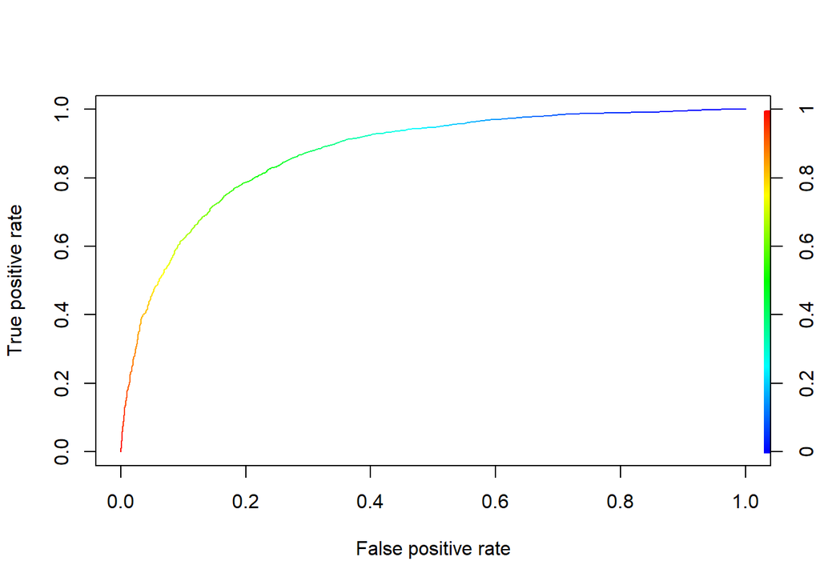

```r
prob=predict(logit_result,Train,type=c("response"))


#ROC curve
predictionsROCR1 = prediction(prob, Train$lactate_label4)
ROCRPerf = performance(predictionsROCR1, "tpr", "fpr")
plot(ROCRPerf, colorize = TRUE,text.adj=c(-0.2,1.7))
```

```r
auc1 = as.numeric(performance(predictionsROCR1,"auc")@y.values)
#Area under the curve
auc1
```

```
## [1] 0.8722861
```

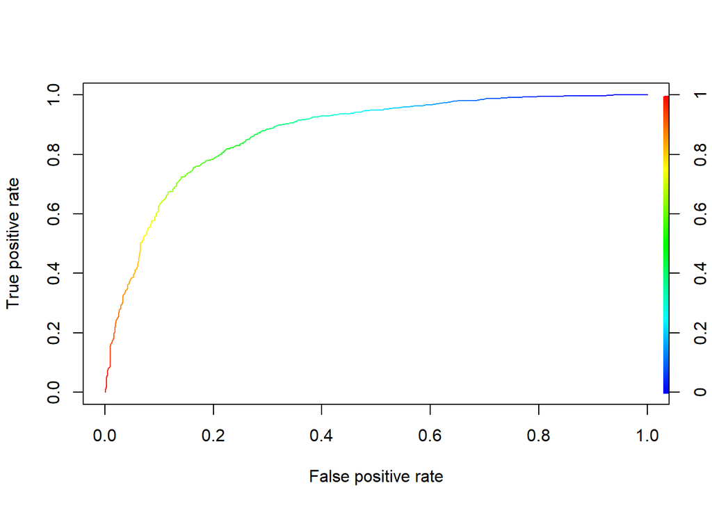

```r
##

pred <- predict(logit_result, Test,type=c("response"))


#ROC curve
require(ROCR)
predictionsROCR2 = prediction(pred, Test$lactate_label4)
ROCRPerf2 = performance(predictionsROCR2, "tpr", "fpr")
plot(ROCRPerf2, colorize = TRUE,text.adj=c(-0.2,1.7))
```

```r
auc2 = as.numeric(performance(predictionsROCR2,"auc")@y.values)
#Area under the curve
auc2
```

```
## [1] 0.8707759
```

## 7.2 - All databases train and test lactate label 6

```r
## train test set
Cohort_Q4_L6 <-Cohort_Q4
Cohort_Q4_L6$lactate_max<-NULL
Cohort_Q4_L6$apache_decile<-NULL
Cohort_Q4_L6$apache_quartile<-NULL
Cohort_Q4_L6$apachescore<-NULL
#grups_quartile4$outcome<-NULL
Cohort_Q4_L6$lactate_label2<-NULL
Cohort_Q4_L6$lactate_label4<-NULL
Cohort_Q4_L6$lactate_quartile<-NULL

#Delete patients with intermidiate lactate level between 2 and 4

Cohort_Q4_L6<- Cohort_Q4_L6[which(Cohort_Q4_L6$lactate_label6!='Intermediate'), ]
Cohort_Q4_L6$lactate_label6<- as.factor(as.character((Cohort_Q4_L6$lactate_label6)))

## 75% of the sample size

library(caret)
set.seed(3456)
trainIndex <- createDataPartition(Cohort_Q4_L6$lactate_label6, p = .75,
                                  list = FALSE,
                                  times = 1)

Train <- Cohort_Q4_L6[ trainIndex,]
Test  <- Cohort_Q4_L6[-trainIndex,]
#GLM
logit_result <- glm(lactate_label6 ~ . -outcome -icu_los -LOS_quartile -PatientID -database, data=Train ,family = 'binomial')

summary(logit_result)
```

```
##
## Call:
## glm(formula = lactate_label6 ~ . - outcome - icu_los - LOS_quartile -
##     PatientID - database, family = "binomial", data = Train)
##
## Deviance Residuals:
##     Min       1Q   Median       3Q      Max
## -3.1978  -0.3578   0.2360   0.5254   3.7155
##
## Coefficients:
##                            Estimate Std. Error z value Pr(>|z|)
## (Intercept)               4.6947451  1.2563685   3.737 0.000186 ***
## bicarbonate_min           0.2587854  0.0147638  17.528  < 2e-16 ***
## bicarbonate_max           0.0650378  0.0150766   4.314 1.60e-05 ***
## bilirubin_max            -0.0625141  0.0136006  -4.596 4.30e-06 ***
## creatinine_max            0.1612201  0.0283853   5.680 1.35e-08 ***
## chlorine_min              0.1256224  0.0127271   9.870  < 2e-16 ***
## chloride_max              0.0988859  0.0129121   7.658 1.88e-14 ***
## glucose_max              -0.0037214  0.0004410  -8.438  < 2e-16 ***
## hemoglobin_min            0.0330815  0.0194653   1.700 0.089223 .
## platelet_min              0.0052138  0.0004661  11.185  < 2e-16 ***
## potassium_min             0.4010010  0.0827031   4.849 1.24e-06 ***
## potassium_max            -0.5027935  0.0549981  -9.142  < 2e-16 ***
## sodium_min               -0.0716737  0.0148308  -4.833 1.35e-06 ***
## sodium_max               -0.1806420  0.0159875 -11.299  < 2e-16 ***
## bun_max                   0.0129800  0.0019075   6.805 1.01e-11 ***
## wbc_min                   0.0557985  0.0085192   6.550 5.76e-11 ***
## wbc_max                  -0.0537067  0.0067329  -7.977 1.50e-15 ***
## alt_max                   0.0003579  0.0001795   1.994 0.046154 *
## ast_max                  -0.0006913  0.0001401  -4.934 8.07e-07 ***
## alkaline_phosphatase_max  0.0002526  0.0002671   0.946 0.344371
## age                       0.0002626  0.0027691   0.095 0.924451
## days_before_icu           0.0092064  0.0063888   1.441 0.149578
## genderM                  -0.3154069  0.0860866  -3.664 0.000248 ***
## vent1                    -0.1253174  0.0891189  -1.406 0.159670
## num_drugsLow_Dose         0.7262547  0.3316967   2.190 0.028559 *
## num_drugsNone             1.5160351  0.3154604   4.806 1.54e-06 ***
## ---
## Signif. codes:  0 '***' 0.001 '**' 0.01 '*' 0.05 '.' 0.1 ' ' 1
##
## (Dispersion parameter for binomial family taken to be 1)
##
##     Null deviance: 7205.6  on 5422  degrees of freedom
## Residual deviance: 3728.2  on 5397  degrees of freedom
## AIC: 3780.2
##
## Number of Fisher Scoring iterations: 7
```

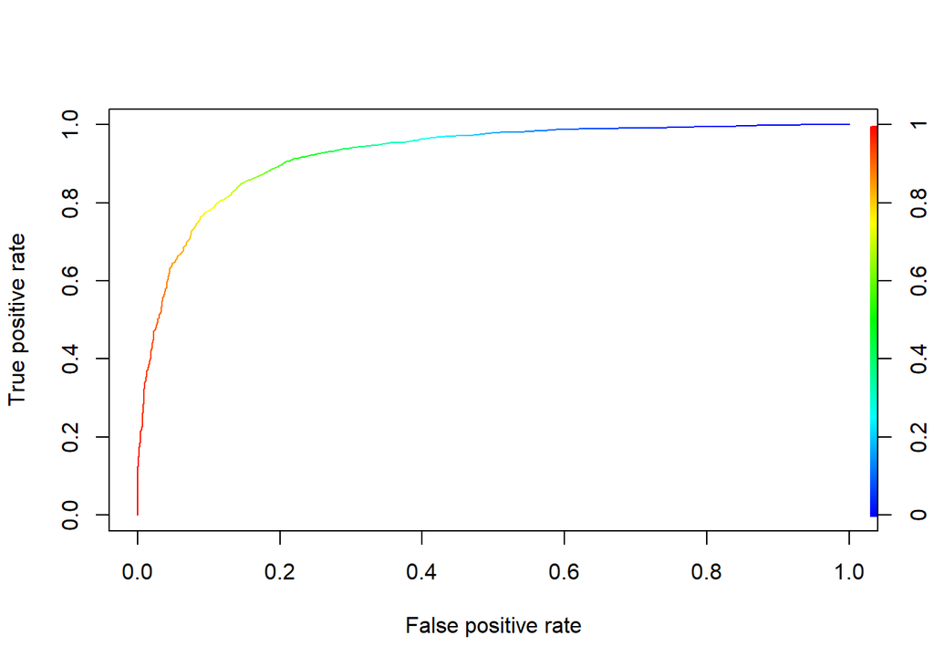

```r
prob=predict(logit_result,Train,type=c("response"))


#ROC curve
require(ROCR)
predictionsROCR1 = prediction(prob, Train$lactate_label6)
ROCRPerf = performance(predictionsROCR1, "tpr", "fpr")
plot(ROCRPerf, colorize = TRUE,text.adj=c(-0.2,1.7))
```

```r
auc1 = as.numeric(performance(predictionsROCR1,"auc")@y.values)
#Area under the curve
auc1
```

```
## [1] 0.9235594
```

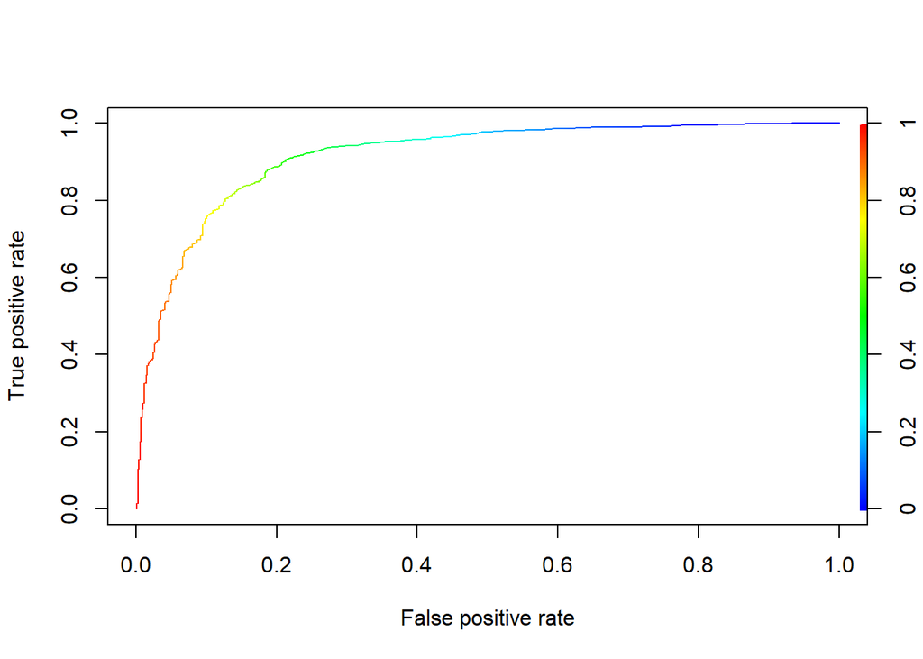

```r
##

pred <- predict(logit_result, Test,type=c("response"))


#ROC curve
require(ROCR)
predictionsROCR2 = prediction(pred, Test$lactate_label6)
ROCRPerf2 = performance(predictionsROCR2, "tpr", "fpr")
plot(ROCRPerf2, colorize = TRUE,text.adj=c(-0.2,1.7))
```

```r
auc2 = as.numeric(performance(predictionsROCR2,"auc")@y.values)
#Area under the curve
auc2
```

```
## [1] 0.9150052
```

## 7.3 - Train HJ23 and test eiCU+MIMI-III lactate label 4

```r
## train test set

Train <- Cohort_Q4_L4[which(Cohort_Q4_L4$database=='HJ23'), ]
Test  <- Cohort_Q4_L4[which(Cohort_Q4_L4$database=='MIMIC' | Cohort_Q4_L4$database=='eICU'),]

Train$database<-NULL
Test$database<-NULL
#GLM
logit_result <- glm(lactate_label4 ~ . -outcome -icu_los -LOS_quartile -PatientID , data=Train, family = 'binomial')

summary(logit_result)
```

```
##
## Call:
## glm(formula = lactate_label4 ~ . - outcome - icu_los - LOS_quartile -
##     PatientID, family = "binomial", data = Train)
##
## Deviance Residuals:
##     Min       1Q   Median       3Q      Max
## -2.7500  -0.5633   0.2922   0.6389   2.5106
##
## Coefficients:
##                            Estimate Std. Error z value Pr(>|z|)
## (Intercept)               5.1477271  3.5737816   1.440 0.149750
## bicarbonate_min           0.0394958  0.0468300   0.843 0.399013
## bicarbonate_max           0.0910080  0.0533836   1.705 0.088233 .
## bilirubin_max            -0.0797958  0.0642812  -1.241 0.214474
## creatinine_max           -0.1507185  0.0916320  -1.645 0.100006
## chlorine_min              0.1346538  0.0462187   2.913 0.003575 **
## chloride_max             -0.0252312  0.0423551  -0.596 0.551372
## glucose_max              -0.0038836  0.0017987  -2.159 0.030842 *
## hemoglobin_min           -0.0289286  0.0609599  -0.475 0.635106
## platelet_min              0.0056436  0.0015579   3.623 0.000292 ***
## potassium_min            -0.2253505  0.2441979  -0.923 0.356101
## potassium_max            -0.1709932  0.1393791  -1.227 0.219890
## sodium_min               -0.0061897  0.0348777  -0.177 0.859139
## sodium_max               -0.1240747  0.0395075  -3.141 0.001686 **
## bun_max                   0.0081369  0.0032397   2.512 0.012018 *
## wbc_min                   0.1054659  0.0363522   2.901 0.003717 **
## wbc_max                  -0.1374647  0.0314284  -4.374 1.22e-05 ***
## alt_max                   0.0022087  0.0020449   1.080 0.280118
## ast_max                  -0.0002236  0.0013445  -0.166 0.867904
## alkaline_phosphatase_max -0.0041855  0.0014573  -2.872 0.004078 **
## age                       0.0102462  0.0111659   0.918 0.358813
## days_before_icu           0.0060103  0.0146991   0.409 0.682623
## genderM                   0.0300805  0.2904630   0.104 0.917518
## vent1                    -0.7040770  0.3619950  -1.945 0.051776 .
## num_drugsLow_Dose         0.9065770  0.5321273   1.704 0.088440 .
## num_drugsNone             2.6004131  0.5741003   4.530 5.91e-06 ***
## ---
## Signif. codes:  0 '***' 0.001 '**' 0.01 '*' 0.05 '.' 0.1 ' ' 1
##
## (Dispersion parameter for binomial family taken to be 1)
##
##     Null deviance: 602.41  on 450  degrees of freedom
## Residual deviance: 371.76  on 425  degrees of freedom
## AIC: 423.76
##
## Number of Fisher Scoring iterations: 7
```

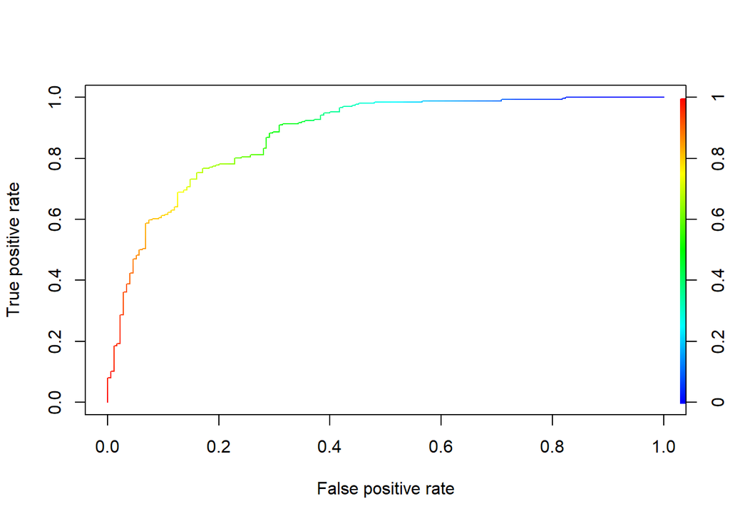

```r
##Train
prob=predict(logit_result,Train,type=c("response"))

#ROC curve
require(ROCR)
predictionsROCR1 = prediction(prob, Train$lactate_label4)
ROCRPerf = performance(predictionsROCR1, "tpr", "fpr")
plot(ROCRPerf, colorize = TRUE,text.adj=c(-0.2,1.7))
```

```r
auc1 = as.numeric(performance(predictionsROCR1,"auc")@y.values)
#Area under the curve
auc1
```

```
## [1] 0.8799379
```

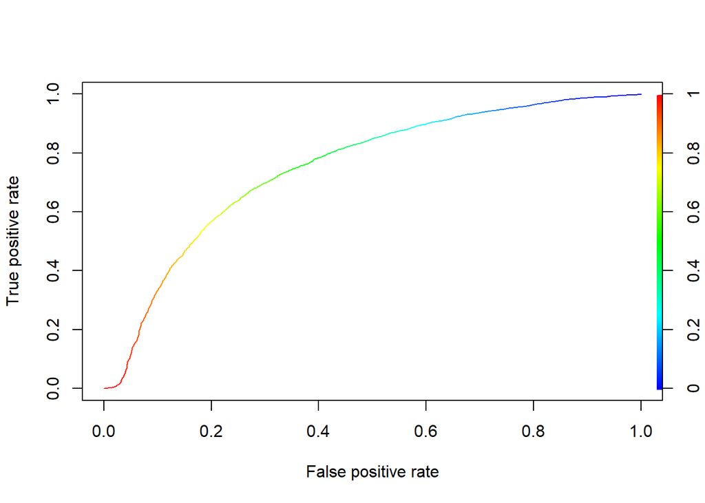

```r
##Test

pred <- predict(logit_result, Test,type=c("response"))


#ROC curve
require(ROCR)
predictionsROCR2 = prediction(pred, Test$lactate_label4)
ROCRPerf2 = performance(predictionsROCR2, "tpr", "fpr")
plot(ROCRPerf2, colorize = TRUE,text.adj=c(-0.2,1.7))
```

```r
auc2 = as.numeric(performance(predictionsROCR2,"auc")@y.values)
#Area under the curve
auc2
```

```
## [1] 0.7501756
```

## 7.4 - Train MIMIC and test eiCU+HJ23 lactate label 4

```r
## train test set

Train <- Cohort_Q4_L4[which(Cohort_Q4_L4$database=='MIMIC'), ]
Test  <- Cohort_Q4_L4[which(Cohort_Q4_L4$database=='HJ23' | Cohort_Q4_L4$database=='eICU'),]

Train$database<-NULL
Test$database<-NULL
#GLM
logit_result <- glm(lactate_label4 ~ . -outcome -icu_los -LOS_quartile -PatientID , data=Train ,family = 'binomial')

summary(logit_result)
```

```
##
## Call:
## glm(formula = lactate_label4 ~ . - outcome - icu_los - LOS_quartile -
##     PatientID, family = "binomial", data = Train)
##
## Deviance Residuals:
##     Min       1Q   Median       3Q      Max
## -3.0710  -0.5849   0.2184   0.6379   3.7611
##
## Coefficients:
##                            Estimate Std. Error z value Pr(>|z|)
## (Intercept)               4.2761242  1.3855479   3.086 0.002027 **
## bicarbonate_min           0.2525228  0.0175377  14.399  < 2e-16 ***
## bicarbonate_max           0.0668388  0.0177901   3.757 0.000172 ***
## bilirubin_max            -0.0613131  0.0141342  -4.338 1.44e-05 ***
## creatinine_max            0.1947436  0.0332026   5.865 4.48e-09 ***
## chlorine_min              0.1613368  0.0138543  11.645  < 2e-16 ***
## chloride_max              0.0544461  0.0139277   3.909 9.26e-05 ***
## glucose_max              -0.0052851  0.0005554  -9.516  < 2e-16 ***
## hemoglobin_min            0.1041547  0.0227544   4.577 4.71e-06 ***
## platelet_min              0.0043130  0.0004239  10.174  < 2e-16 ***
## potassium_min             0.2144488  0.0902518   2.376 0.017496 *
## potassium_max            -0.4894953  0.0566149  -8.646  < 2e-16 ***
## sodium_min               -0.0198578  0.0149123  -1.332 0.182979
## sodium_max               -0.2199385  0.0185009 -11.888  < 2e-16 ***
## bun_max                   0.0141729  0.0023291   6.085 1.16e-09 ***
## wbc_min                   0.0660838  0.0097696   6.764 1.34e-11 ***
## wbc_max                  -0.0570357  0.0071920  -7.930 2.18e-15 ***
## alt_max                   0.0004649  0.0002326   1.998 0.045679 *
## ast_max                  -0.0006570  0.0001969  -3.337 0.000846 ***
## alkaline_phosphatase_max  0.0007404  0.0003149   2.351 0.018700 *
## age                       0.0005757  0.0029480   0.195 0.845167
## days_before_icu          -0.0009386  0.0053500  -0.175 0.860731
## genderM                  -0.1411849  0.0866689  -1.629 0.103310
## vent1                    -0.0016338  0.1312402  -0.012 0.990067
## num_drugsLow_Dose         0.2904794  0.2905116   1.000 0.317364
## num_drugsNone             0.7236410  0.2748120   2.633 0.008458 **
## ---
## Signif. codes:  0 '***' 0.001 '**' 0.01 '*' 0.05 '.' 0.1 ' ' 1
##
## (Dispersion parameter for binomial family taken to be 1)
##
##     Null deviance: 6002.5  on 4349  degrees of freedom
## Residual deviance: 3528.7  on 4324  degrees of freedom
## AIC: 3580.7
##
## Number of Fisher Scoring iterations: 7
```

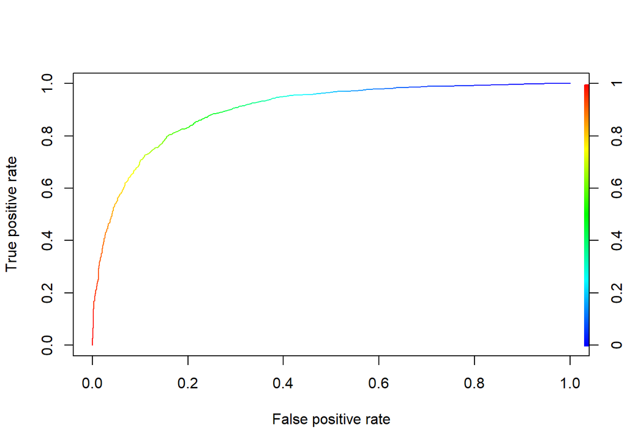

```r
##Train
prob=predict(logit_result,Train,type=c("response"))

#ROC curve
require(ROCR)
predictionsROCR1 = prediction(prob, Train$lactate_label4)
ROCRPerf = performance(predictionsROCR1, "tpr", "fpr")
plot(ROCRPerf, colorize = TRUE,text.adj=c(-0.2,1.7))
```

```r
auc1 = as.numeric(performance(predictionsROCR1,"auc")@y.values)
#Area under the curve
auc1
```

```
## [1] 0.8988224
```

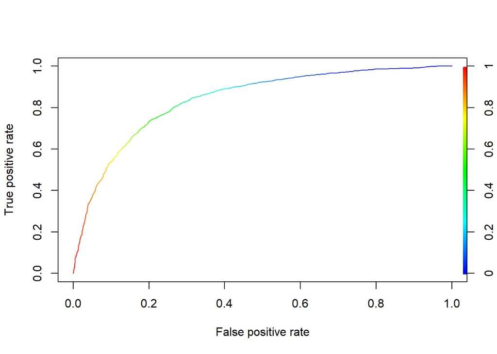

```r
##Test

pred <- predict(logit_result, Test,type=c("response"))


#ROC curve
require(ROCR)
predictionsROCR2 = prediction(pred, Test$lactate_label4)
ROCRPerf2 = performance(predictionsROCR2, "tpr", "fpr")
plot(ROCRPerf2, colorize = TRUE,text.adj=c(-0.2,1.7))
```

```r
auc2 = as.numeric(performance(predictionsROCR2,"auc")@y.values)
#Area under the curve
auc2
```

```
## [1] 0.8388548
```

## 7.5 - Train eICU and test MIMIC+HJ23 lactate label 4

```r
## train test set

Train <- Cohort_Q4_L4[which(Cohort_Q4_L4$database=='eICU'), ]
Test  <- Cohort_Q4_L4[which(Cohort_Q4_L4$database=='HJ23' | Cohort_Q4_L4$database=='MIMIC'),]

Train$database<-NULL
Test$database<-NULL
#GLM
logit_result <- glm(lactate_label4 ~ . -outcome -icu_los -LOS_quartile -PatientID , data=Train ,family = 'binomial')

summary(logit_result)
```

```
##
## Call:
## glm(formula = lactate_label4 ~ . - outcome - icu_los - LOS_quartile -
##     PatientID, family = "binomial", data = Train)
##
## Deviance Residuals:
##     Min       1Q   Median       3Q      Max
## -2.7548  -0.7468  -0.1622   0.7587   3.6512
##
## Coefficients:
##                            Estimate Std. Error z value Pr(>|z|)
## (Intercept)               9.895e-01  1.970e+02   0.005 0.995992
## bicarbonate_min           2.031e-01  1.428e-02  14.219  < 2e-16 ***
## bicarbonate_max           4.937e-02  1.380e-02   3.578 0.000346 ***
## bilirubin_max            -8.878e-02  1.630e-02  -5.447 5.13e-08 ***
## creatinine_max            9.933e-02  2.624e-02   3.786 0.000153 ***
## chlorine_min              8.853e-02  1.198e-02   7.393 1.44e-13 ***
## chloride_max              9.162e-02  1.259e-02   7.279 3.36e-13 ***
## glucose_max              -3.407e-03  4.324e-04  -7.881 3.25e-15 ***
## hemoglobin_min           -3.509e-02  1.722e-02  -2.037 0.041615 *
## platelet_min              3.783e-03  4.677e-04   8.087 6.09e-16 ***
## potassium_min             2.435e-01  8.064e-02   3.020 0.002531 **
## potassium_max            -3.980e-01  6.136e-02  -6.486 8.81e-11 ***
## sodium_min               -8.916e-02  1.469e-02  -6.071 1.27e-09 ***
## sodium_max               -1.226e-01  1.549e-02  -7.916 2.46e-15 ***
## bun_max                   1.818e-02  2.078e-03   8.747  < 2e-16 ***
## wbc_min                   1.965e-02  8.826e-03   2.226 0.025988 *
## wbc_max                  -2.805e-02  6.880e-03  -4.077 4.56e-05 ***
## alt_max                   3.312e-05  2.397e-04   0.138 0.890098
## ast_max                  -5.725e-04  1.594e-04  -3.593 0.000327 ***
## alkaline_phosphatase_max  4.468e-04  3.577e-04   1.249 0.211602
## age                      -1.024e-02  2.672e-03  -3.831 0.000127 ***
## days_before_icu          -3.320e-04  2.702e-03  -0.123 0.902228
## genderM                  -1.654e-01  8.067e-02  -2.050 0.040337 *
## vent1                    -2.723e-01  8.098e-02  -3.363 0.000771 ***
## num_drugsLow_Dose         5.565e+00  1.970e+02   0.028 0.977460
## num_drugsNone             6.079e+00  1.970e+02   0.031 0.975380
## ---
## Signif. codes:  0 '***' 0.001 '**' 0.01 '*' 0.05 '.' 0.1 ' ' 1
##
## (Dispersion parameter for binomial family taken to be 1)
##
##     Null deviance: 5897.9  on 4316  degrees of freedom
## Residual deviance: 3987.0  on 4291  degrees of freedom
## AIC: 4039
##
## Number of Fisher Scoring iterations: 10
```

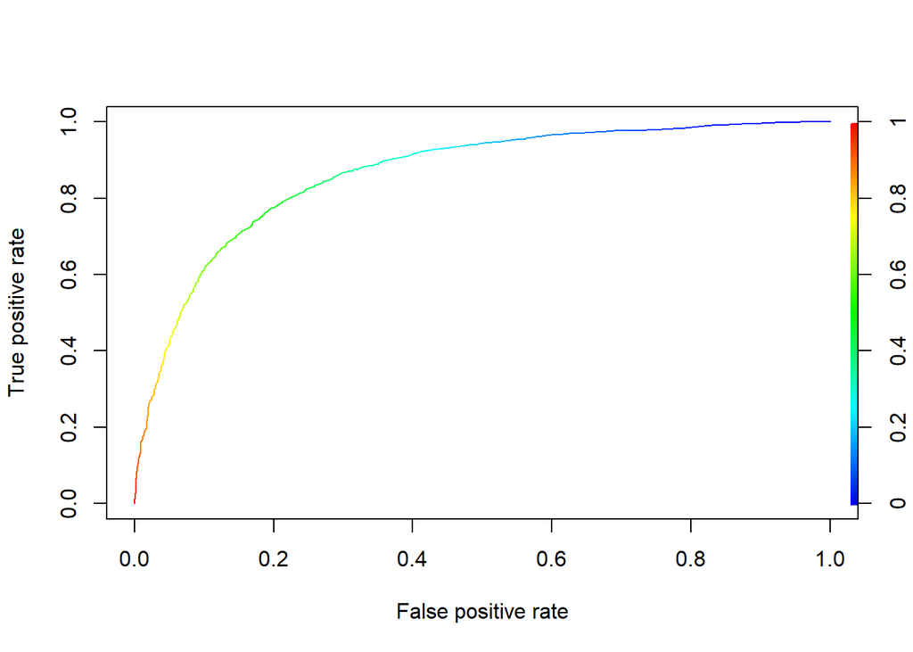

```r
##Train
prob=predict(logit_result,Train,type=c("response"))

#ROC curve
require(ROCR)
predictionsROCR1 = prediction(prob, Train$lactate_label4)
ROCRPerf = performance(predictionsROCR1, "tpr", "fpr")
plot(ROCRPerf, colorize = TRUE,text.adj=c(-0.2,1.7))
```

```r
auc1 = as.numeric(performance(predictionsROCR1,"auc")@y.values)
#Area under the curve
auc1
```

```
## [1] 0.8640199
```

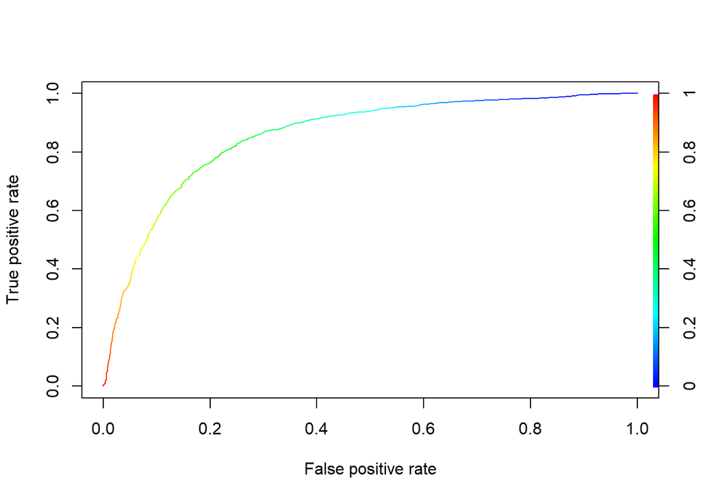

```r
##Test

pred <- predict(logit_result, Test,type=c("response"))


#ROC curve
require(ROCR)
predictionsROCR2 = prediction(pred, Test$lactate_label4)
ROCRPerf2 = performance(predictionsROCR2, "tpr", "fpr")
plot(ROCRPerf2, colorize = TRUE,text.adj=c(-0.2,1.7))
```

```r
auc2 = as.numeric(performance(predictionsROCR2,"auc")@y.values)
#Area under the curve
auc2
```

```
## [1] 0.8559699
```

## 7.6 - Train HJ23 and test eiCU+MIMIC lactate label 6

```r
## train test set

Train <- Cohort_Q4_L6[which(Cohort_Q4_L6$database=='HJ23'), ]
Test  <- Cohort_Q4_L6[which(Cohort_Q4_L6$database=='MIMIC' | Cohort_Q4_L6$database=='eICU'),]

Train$database<-NULL
Test$database<-NULL
#GLM
logit_result <- glm(lactate_label6 ~ . -outcome -icu_los -LOS_quartile -PatientID , data=Train ,family = 'binomial')

summary(logit_result)
```

```
##
## Call:
## glm(formula = lactate_label6 ~ . - outcome - icu_los - LOS_quartile -
##     PatientID, family = "binomial", data = Train)
##
## Deviance Residuals:
##      Min        1Q    Median        3Q       Max
## -2.93571  -0.01361   0.09049   0.34730   2.04975
##
## Coefficients:
##                            Estimate Std. Error z value Pr(>|z|)
## (Intercept)               1.230e+01  5.621e+00   2.189 0.028602 *
## bicarbonate_min           1.560e-01  7.361e-02   2.120 0.034016 *
## bicarbonate_max           8.634e-02  7.707e-02   1.120 0.262544
## bilirubin_max            -9.710e-02  9.478e-02  -1.024 0.305607
## creatinine_max           -2.439e-01  1.637e-01  -1.490 0.136315
## chlorine_min              3.099e-01  7.655e-02   4.048 5.16e-05 ***
## chloride_max             -7.805e-02  6.231e-02  -1.253 0.210347
## glucose_max              -5.931e-03  2.687e-03  -2.208 0.027270 *
## hemoglobin_min           -5.544e-02  9.805e-02  -0.565 0.571794
## platelet_min              1.006e-02  2.704e-03   3.722 0.000198 ***
## potassium_min             2.608e-01  4.051e-01   0.644 0.519665
## potassium_max            -8.131e-02  2.683e-01  -0.303 0.761822
## sodium_min                1.951e-03  5.267e-02   0.037 0.970453
## sodium_max               -2.934e-01  6.445e-02  -4.552 5.31e-06 ***
## bun_max                   1.634e-02  5.321e-03   3.071 0.002132 **
## wbc_min                   2.324e-01  5.706e-02   4.074 4.62e-05 ***
## wbc_max                  -2.518e-01  5.138e-02  -4.900 9.58e-07 ***
## alt_max                   2.416e-03  4.259e-03   0.567 0.570490
## ast_max                  -1.898e-05  1.630e-03  -0.012 0.990710
## alkaline_phosphatase_max -3.526e-03  3.731e-03  -0.945 0.344652
## age                      -1.068e-02  1.809e-02  -0.591 0.554823
## days_before_icu           1.171e-02  2.478e-02   0.473 0.636499
## genderM                  -6.259e-01  4.724e-01  -1.325 0.185156
## vent1                    -3.000e-01  5.602e-01  -0.536 0.592236
## num_drugsLow_Dose         8.683e-01  7.213e-01   1.204 0.228697
## num_drugsNone             4.300e+00  9.207e-01   4.671 3.00e-06 ***
## ---
## Signif. codes:  0 '***' 0.001 '**' 0.01 '*' 0.05 '.' 0.1 ' ' 1
##
## (Dispersion parameter for binomial family taken to be 1)
##
##     Null deviance: 430.23  on 373  degrees of freedom
## Residual deviance: 168.98  on 348  degrees of freedom
## AIC: 220.98
##
## Number of Fisher Scoring iterations: 7
```

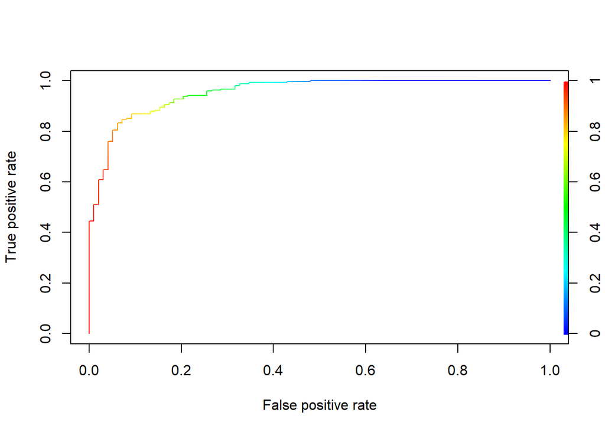

```r
##Train
prob=predict(logit_result,Train,type=c("response"))

#ROC curve
require(ROCR)
predictionsROCR1 = prediction(prob, Train$lactate_label6)
ROCRPerf = performance(predictionsROCR1, "tpr", "fpr")
plot(ROCRPerf, colorize = TRUE,text.adj=c(-0.2,1.7))
```

```r
auc1 = as.numeric(performance(predictionsROCR1,"auc")@y.values)
#Area under the curve
auc1
```

```
## [1] 0.9541186
```

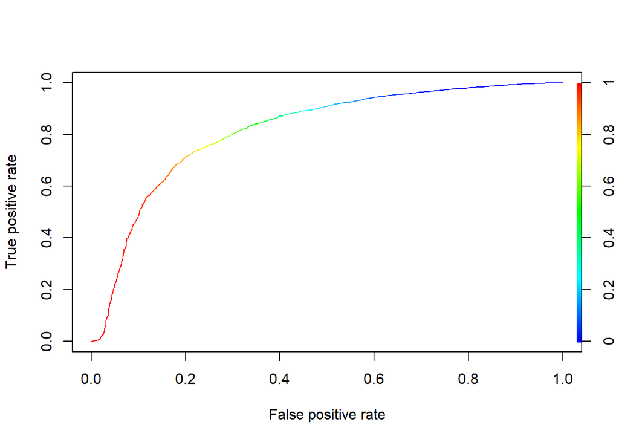

```r
##Test

pred <- predict(logit_result, Test,type=c("response"))


#ROC curve
require(ROCR)
predictionsROCR2 = prediction(pred, Test$lactate_label6)
ROCRPerf2 = performance(predictionsROCR2, "tpr", "fpr")
plot(ROCRPerf2, colorize = TRUE,text.adj=c(-0.2,1.7))
```

```r
auc2 = as.numeric(performance(predictionsROCR2,"auc")@y.values)
#Area under the curve
auc2
```

```
## [1] 0.8152439
```

## 7.7 - Train MIMIC3 and test eiCU+HJ23 lactate label 6

```r
## train test set

Train <- Cohort_Q4_L6[which(Cohort_Q4_L6$database=='MIMIC'), ]
Test  <- Cohort_Q4_L6[which(Cohort_Q4_L6$database=='HJ23' | Cohort_Q4_L6$database=='eICU'),]

Train$database<-NULL
Test$database<-NULL
#GLM
logit_result <- glm(lactate_label6 ~ . -outcome -icu_los -LOS_quartile -PatientID , data=Train ,family = 'binomial')

summary(logit_result)
```

```
##
## Call:
## glm(formula = lactate_label6 ~ . - outcome - icu_los - LOS_quartile -
##     PatientID, family = "binomial", data = Train)
##
## Deviance Residuals:
##     Min       1Q   Median       3Q      Max
## -2.9540  -0.1237   0.1799   0.4102   3.8469
##
## Coefficients:
##                            Estimate Std. Error z value Pr(>|z|)
## (Intercept)               3.9180398  1.9091895   2.052 0.040150 *
## bicarbonate_min           0.3315047  0.0231399  14.326  < 2e-16 ***
## bicarbonate_max           0.0693941  0.0236978   2.928 0.003408 **
## bilirubin_max            -0.0663135  0.0163136  -4.065 4.80e-05 ***
## creatinine_max            0.2530420  0.0464731   5.445 5.18e-08 ***
## chlorine_min              0.1688113  0.0177240   9.524  < 2e-16 ***
## chloride_max              0.1226981  0.0188973   6.493 8.42e-11 ***
## glucose_max              -0.0052218  0.0006537  -7.988 1.38e-15 ***
## hemoglobin_min            0.1630828  0.0320703   5.085 3.67e-07 ***
## platelet_min              0.0060168  0.0006328   9.508  < 2e-16 ***
## potassium_min             0.2796668  0.1233807   2.267 0.023409 *
## potassium_max            -0.5775946  0.0743339  -7.770 7.83e-15 ***
## sodium_min               -0.0112932  0.0173087  -0.652 0.514107
## sodium_max               -0.2983523  0.0245870 -12.135  < 2e-16 ***
## bun_max                   0.0182096  0.0032696   5.569 2.56e-08 ***
## wbc_min                   0.1130900  0.0149583   7.560 4.02e-14 ***
## wbc_max                  -0.0832603  0.0095166  -8.749  < 2e-16 ***
## alt_max                   0.0001727  0.0002413   0.716 0.474042
## ast_max                  -0.0004789  0.0001827  -2.621 0.008774 **
## alkaline_phosphatase_max  0.0006779  0.0004206   1.612 0.107042
## age                       0.0050202  0.0039934   1.257 0.208709
## days_before_icu          -0.0019182  0.0066444  -0.289 0.772812
## genderM                  -0.3112075  0.1242072  -2.506 0.012226 *
## vent1                    -0.2645289  0.2009832  -1.316 0.188116
## num_drugsLow_Dose         0.7697972  0.3868189   1.990 0.046583 *
## num_drugsNone             1.2272472  0.3646662   3.365 0.000764 ***
## ---
## Signif. codes:  0 '***' 0.001 '**' 0.01 '*' 0.05 '.' 0.1 ' ' 1
##
## (Dispersion parameter for binomial family taken to be 1)
##
##     Null deviance: 4265.7  on 3425  degrees of freedom
## Residual deviance: 1855.5  on 3400  degrees of freedom
## AIC: 1907.5
##
## Number of Fisher Scoring iterations: 7
```

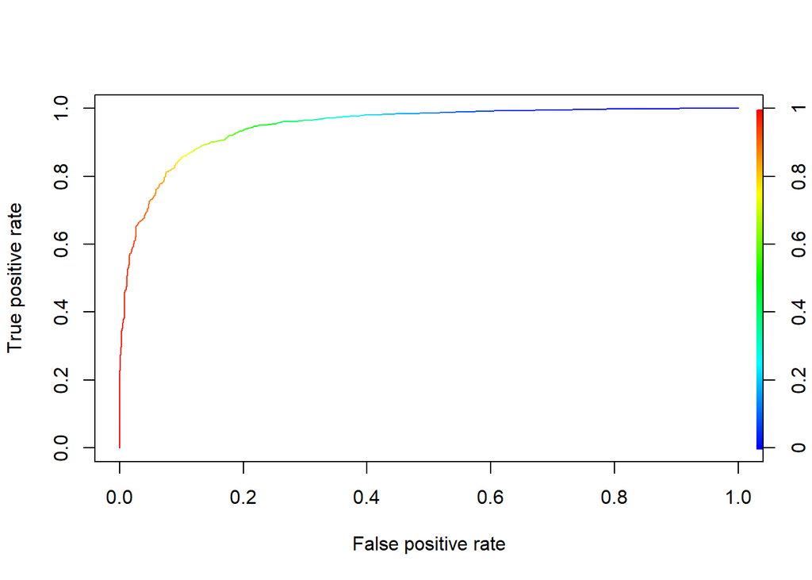

```r
##Train
prob=predict(logit_result,Train,type=c("response"))

#ROC curve
require(ROCR)
predictionsROCR1 = prediction(prob, Train$lactate_label6)
ROCRPerf = performance(predictionsROCR1, "tpr", "fpr")
plot(ROCRPerf, colorize = TRUE,text.adj=c(-0.2,1.7))
```

```r
auc1 = as.numeric(performance(predictionsROCR1,"auc")@y.values)
#Area under the curve
auc1
```

```
## [1] 0.9477792
```

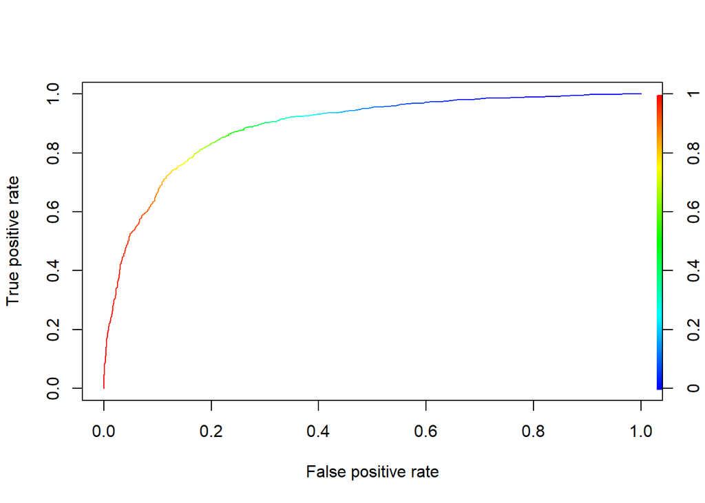

```r
##Test

pred <- predict(logit_result, Test,type=c("response"))


#ROC curve
require(ROCR)
predictionsROCR2 = prediction(pred, Test$lactate_label6)
ROCRPerf2 = performance(predictionsROCR2, "tpr", "fpr")
plot(ROCRPerf2, colorize = TRUE,text.adj=c(-0.2,1.7))
```

```r
auc2 = as.numeric(performance(predictionsROCR2,"auc")@y.values)
#Area under the curve
auc2
```

```
## [1] 0.8884545
```